# Identifying zebrafish liver cell populations by comparing zebrafish bulk RNA-seq to human scRNA-seq data

Michal Pawlak

2019-03-20

## Introduction

By using FACS and transgenic zebrafish lines we have isolated 3 liver cell populations which likely correspond to hepatocytes (hep), hepatic stellate cells (hsc) and endothelial cells (ec). Bulk RNA-seq has been performed to each of these cell polulations. We have also used whole liver RNA-seq data as a control. We would like to match zebrafish liver cell populations with human liver sc-RNAseq to better describe transcriptomic profile of zebrafish cell populations and define their similarity to corresponding human liver cell populations. For scRNA-seq data we refer to [Nature Communications paper by MacParland et al., 2018.](https://www.nature.com/articles/s41467-018-06318-7).

```r
library(readxl)
library(tidyr)
library(httr)

#getting raw counts from bulk RNAseq zebrafish experiment
url_1 <- "https://www.dropbox.com/s/64ab1vhajravj09/star_counts.RDS?dl=1"
suppressMessages(GET(url_1, write_disk("star_counts.RDS", overwrite=TRUE)))
```

```
## Response [https://uc5dc3f2d83f0c463d57500385cb.dl.dropboxusercontent.com/cd/0/get/Adb3R0C49PgmtFEHa9ISUb--WXcfvOjuqjPt5TovJLALrx6TVCr10zE8wcEN2-TkJ19l3qr8PDPmRhu_sdQounVpiFdbJf_kx_P8U0zzfXFozoX_b058oMXTgLmfqvkHVQc/file?dl=1]
##   Date: 2019-03-20 09:06
##   Status: 200
##   Content-Type: application/binary
##   Size: 326 kB
## <ON DISK>  C:\Users\mpawlak\Desktop\NGS_liver\star_counts.RDS
```

```r
star_counts <- readRDS("star_counts.RDS")

#getting average counts per million (cpm) for top 20 clusters scRNA-seq (downloaded from Nature Comm paper)
url_2 <- "https://www.dropbox.com/s/mskn2mp9gxfb9xb/41467_2018_6318_MOESM4_ESM.xlsx?dl=1"
suppressMessages(GET(url_2, write_disk("scRNAseq.xlsx", overwrite=TRUE)))
```

```
## Response [https://uccae84593ca9fb9f1a7012f2f7d.dl.dropboxusercontent.com/cd/0/get/AdbK9NLczx-w-eeBq8g9Cd28Yb5eY_vpk_q7mouapaPhihOlFvtz_zfy8T7yZoTZWoQhDqifCyNMAAfDyGAlURKoDkC7Iiw0PqwhYEZZXXvxwjXIV1zRITKRiGuf_NZNGcA/file?dl=1]
##   Date: 2019-03-20 09:06
##   Status: 200
##   Content-Type: application/binary
##   Size: 4.72 MB
## <ON DISK>  C:\Users\mpawlak\Desktop\NGS_liver\scRNAseq.xlsx
```

```r
path <- "scRNAseq.xlsx"

#Reading xlsx file as a list
tmp1 <-
  lapply(excel_sheets(path),
  read_excel,
  skip = 1,
  path = path)
```

## Searching for human-zebrafish orthologs

To be able to compare zebrafish and human datasets we are going to identify one to one orthologs of human genes and the genes expressed in liver zerbafish cell populations. For that we are going to use `biomaRt`.

```r
library(biomaRt)
library(dplyr)

tmp2 <- list()
#filtering data to get hgnc symbol and cpm data only
for (i in 1:length(tmp1))
{
  tmp2[[i]] <- tmp1[[i]][, c(1, 7)]
  names(tmp2)[i] <- paste0("cluster", i, sep = " ")
  colnames(tmp2[[i]]) <- c("hgnc_symbol", "mean_cpm")
}

#biomart: getting one2one zebrafish orthologs
zebra <- useMart("ensembl", dataset = "drerio_gene_ensembl")
human <- useMart("ensembl", dataset = "hsapiens_gene_ensembl")

#creating a list of orthologs matching to list from scRNAseq data
tmp3 <- list()
for (i in 1:length(tmp2))
{
  tmp3[[i]] <- getLDS(
  filters = "hgnc_symbol",
  attributes = c("hgnc_symbol"),
  attributesL = c("ensembl_gene_id", "hsapiens_homolog_orthology_type"),
  values = tmp2[[1]]$hgnc_symbol,
  mart = human, martL = zebra,
  bmHeader = TRUE,
  uniqueRows = TRUE
  ) %>% dplyr::filter(Human.homology.type == "ortholog_one2one")
  names(tmp3)[i] <- names(tmp2)[i]
  tmp3[[i]]$Cluster <- paste("cluster", i, sep = " ")
  colnames(tmp3[[i]]) <- c("hgnc_symbol", "ensembl_gene_id", "ortholog", "cluster")
}

#filtering original scRNAseq data to 1) keep only one2one orthologs; 2) ensembl_gene_id present in zebrafish liver data
keep <- rowSums(star_counts) >= 10
zebra_counts <- star_counts[keep,] #filtering zebrafish data to get only expressed genes

tmp4 <- list()
for (i in 1:length(tmp1))
{
  tmp4[[i]] <- dplyr::inner_join(tmp2[[i]], tmp3[[i]], by = "hgnc_symbol")
  tmp4[[i]] <- tmp4[[i]][tmp4[[i]]$ensembl_gene_id %in% rownames(zebra_counts), ]
}

knitr::kable(head(tmp1[[1]], 10), caption = "Representative view of cluster 1 liver scRNA-seq")
```

Representative view of cluster 1 liver scRNA-seq

| Genes | P value (cut-off 0.05) | Average difference (log2 fold difference in CPM (counts per million)) | pct.1 (percentage of cells in selected cluster expressing the gene) | pct.2 (percentage of cells in all the clusters expressing the gene) | Family-wise error rate (Fwer) | Mean (CPM average expression level for selected cluster) |
| --- | --- | --- | --- | --- | --- | --- |
| RPP25L | 1.35019045515366e-66 | 0.653123100193585 | 0.311 | 0.111 | 2.52256082736358e-62 | 0.338213519232057 |
| HSD11B1 | 0 | 0.518047159481852 | 0.896 | 0.207 | 0 | 1.97796905345655 |
| HAMP | 2.91986568178429e-120 | 0.509717351715101 | 0.656 | 0.298 | 5.63972056436635e-116 | 2.36875038119029 |
| GHR | 1.2443177189201e-96 | 0.483706405368374 | 0.375 | 0.104 | 2.37726900199686e-92 | 0.458225647236047 |
| APOM | 0 | 0.478960588283827 | 0.913 | 0.204 | 0 | 2.09347334225897 |
| APOC4-APOC2 | 4.09588987436005e-210 | 0.473118960016605 | 0.473 | 0.081 | 8.06644551856469e-206 | 0.562633608290747 |
| TKFC | 7.45947653054542e-115 | 0.446063285549388 | 0.383 | 0.1 | 1.4374411274361e-110 | 0.446975661685017 |
| G6PC | 3.58445524325943e-185 | 0.36695301925612 | 0.543 | 0.134 | 7.04022854328585e-181 | 0.745373921840183 |
| G0S2 | 4.34259686359471e-103 | 0.354892599563045 | 0.383 | 0.106 | 8.32649522625651e-99 | 0.544175906086335 |
| PON3 | 0 | 0.353675748280456 | 0.858 | 0.177 | 0 | 1.7165351361998 |

```r
knitr::kable(head(tmp4[[1]], 10), caption = "Representative view of cluster's 1 one2one human-zebrafish orthologs")
```

Representative view of cluster’s 1 one2one human-zebrafish orthologs

| hgnc_symbol | mean_cpm | ensembl_gene_id | ortholog | cluster |
| --- | --- | --- | --- | --- |
| RPP25L | 0.338213519232057 | ENSDARG00000070131 | ortholog_one2one | cluster 1 |
| HAMP | 2.36875038119029 | ENSDARG00000102175 | ortholog_one2one | cluster 1 |
| TKFC | 0.446975661685017 | ENSDARG00000062085 | ortholog_one2one | cluster 1 |
| G0S2 | 0.544175906086335 | ENSDARG00000078859 | ortholog_one2one | cluster 1 |
| C1orf53 | 0.234409817490933 | ENSDARG00000071439 | ortholog_one2one | cluster 1 |
| TTC36 | 1.58503170105325 | ENSDARG00000011693 | ortholog_one2one | cluster 1 |
| MCC | 0.170653208027516 | ENSDARG00000105237 | ortholog_one2one | cluster 1 |
| F10 | 0.773577990834348 | ENSDARG00000088581 | ortholog_one2one | cluster 1 |
| PROX1 | 0.774313683106238 | ENSDARG00000055158 | ortholog_one2one | cluster 1 |
| MRPS35 | 0.254757778884479 | ENSDARG00000038456 | ortholog_one2one | cluster 1 |

## Identifying most expressed genes in every scRNA-seq cluster and correlating them with zebrafish orthologs

We take `n` top expressed genes from every scRNA-seq cluster and combine with corresponding expression from zebrafish RNA-seq. Raw counts are normalized to counts per million (CPM) and then scaled as z-score. Finally Spearman correlation was performed between scRNA-seq clusters and zebrafish bulk RNA-seq.

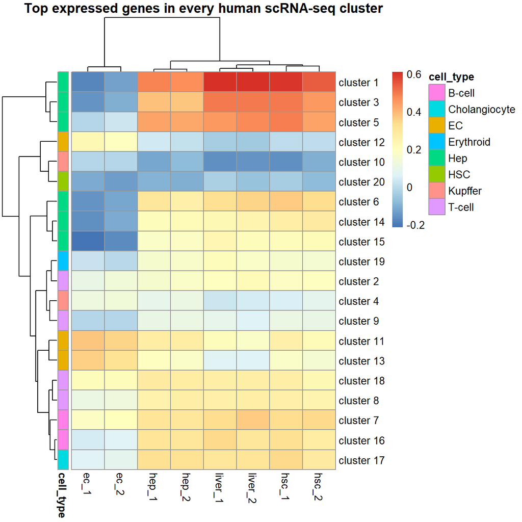

```r
library(ggplot2)
library(pheatmap)

#select n top genes from every cluster
gene_number <- 20 #play with the number
tmp5 <- list()
for (i in 1:length(tmp4))
{
  tmp5[[i]] <- tmp4[[i]][order(tmp4[[i]]$mean_cpm, na.last = NA, decreasing = TRUE)[1:gene_number], -4]
}

#list of marker genes for each cluster - unique in the cluster
marker_genes <- unique(unlist(lapply(tmp5, `[`, "hgnc_symbol")))

#filter on marker genes
tmp6 <- list()
for (i in 1:length(tmp4)) {
  tmp6[[i]] <- tmp4[[i]][tmp4[[i]]$hgnc_symbol %in% marker_genes, -4]
}

#collapse list to data.frame
tmp7 <- bind_rows(tmp6)

#change to wide format
clusters_cpm <- spread(tmp7, cluster, mean_cpm)

zebra_cpm_tmp1 <- as.data.frame(apply(zebra_counts, 2, function(x) (x / sum(x)) * 1000000))
zebra_cpm_tmp2 <- tibble::rownames_to_column(zebra_cpm_tmp1, var = "ensembl_gene_id")
zebra_cpm_tmp3 <- inner_join(zebra_cpm_tmp2, clusters_cpm, by = "ensembl_gene_id")
rownames(zebra_cpm_tmp3) <- zebra_cpm_tmp3$ensembl_gene_id
zebra_cpm <- select(zebra_cpm_tmp3, -ensembl_gene_id, -hgnc_symbol)
zebra_cpm <- apply(zebra_cpm, 2, as.numeric)
zebra_cpm[is.na(zebra_cpm)] <- 0
zebra_cpm_zscore <- scale(zebra_cpm, center = TRUE, scale = TRUE)
cor_zebra <- cor(zebra_cpm_zscore, method = "spearman")
cor_zebra <- cor_zebra[-c(1:8), c(1:8)]

cluster_cell <- data.frame("cell_type" = c("Hep", "Kupffer", "EC", "EC", "EC", "Hep", "Hep", "B-cell", "Cholangiocyte", "T-cell", "Erythroid", "T-cell", "HSC", "Hep", "Kupffer", "Hep", "Hep", "B-cell", "T-cell", "T-cell"))
rownames(cluster_cell) <- rownames(cor_zebra)
pheatmap(cor_zebra, main = "Top expressed genes in every human scRNA-seq cluster", clustering_distance_rows = "euclidean", annotation_row = cluster_cell)
```

Here we use top `n` variable genes that vary between scRNA-seq clusters and correlate them with corresponding genes in zebrafish.

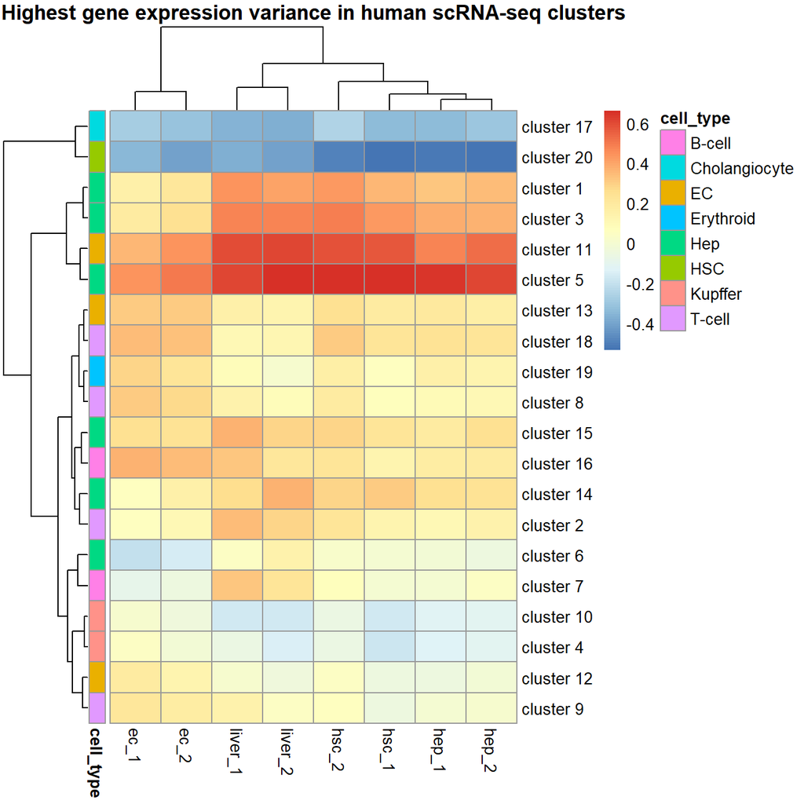

```r
temp_var1 <- dplyr::bind_rows(tmp4) %>% dplyr::select(-ortholog)
temp_var2 <- spread(temp_var1, cluster, mean_cpm)
temp_var2 <- as.data.frame(temp_var2)
rownames(temp_var2) <- temp_var2$ensembl_gene_id
var_genes <- apply(temp_var2[,-c(1,2)], 1, var, na.rm = TRUE)
select_var <- names(sort(var_genes, decreasing=TRUE))[1:gene_number] #play with number
temp_var3 <- temp_var2[select_var,]
temp_var4 <- inner_join(zebra_cpm_tmp2, temp_var3, by = "ensembl_gene_id")
rownames(temp_var4) <- temp_var4$ensembl_gene_id
temp_var5 <- select(temp_var4, -ensembl_gene_id, -hgnc_symbol)
temp_var6 <- apply(temp_var5, 2, as.numeric)
temp_var6[is.na(temp_var6)] <- 0
variance_zscore <- scale(temp_var6, center = TRUE, scale = TRUE)
cor_variance_zscore <- cor(variance_zscore, method = "spearman")
cor_variance_zscore <- cor_variance_zscore[-c(1:8), c(1:8)]
pheatmap(cor_variance_zscore, main = "Highest gene expression variance in human scRNA-seq clusters", clustering_distance_rows = "euclidean", annotation_row = cluster_cell)
```